# CodeLab 3: Classifacton of WLANs power saving

## Task 4: Multi-class classification

Multi-class classification predicts the best among a set of labels (four, in this case). We consider two different model classes (logistic regression and SVM) and within the logistic regression model, both the One vs. All and the multi-class approach.  
The One vs. All (called ‘one versus rest’ in sklearn) method constructs binary classifiers for each class. The final prediction is based on the model with the highest score or the largest (signed) distance from the classification boundary.

-Split the data (X, and y_mc) into training (75%) and test sets (25%) using the “train_test_split” function from Sklearn. Use 4720 as the random state parameter to control the split.

```python
Test_ratio = 0.25
Shuffle_state = 4720
X_train_mc, X_test_mc, y_train_mc, y_test_mc = train_test_split(X_scaled,y_mc_data,test_size=Test_ratio,random_state=Shuffle_state)
```

-Develop and train a logistic regression model using the one vs. rest (parameter multi_class=’ovr’) method using the “y_mc” label vector.

```python
clf_lr_ovr = LogisticRegression(
    multi_class='ovr',
    solver='lbfgs',
    max_iter=1000,
    random_state=4720
)

# Train the model
clf_lr_ovr.fit(X_train_mc, y_train_mc)

# Make predictions
y_prediction_lrovr = clf_lr_ovr.predict(X_test_mc)
```

− Calculate and print the accuracy of the model.

```python
#Accuracy of OVR LR
Accuracy_lrovr = accuracy_score(y_test_mc,y_prediction_lrovr)
print("Accuracy: " + str(Accuracy_lrovr))
```

```
Accuracy: 0.8698224852071006
```

−Generate and plot the confusion matrix.

```
<sklearn.metrics._plot.confusion_matrix.ConfusionMatrixDisplay at 0x1c003fdd7f0>
```

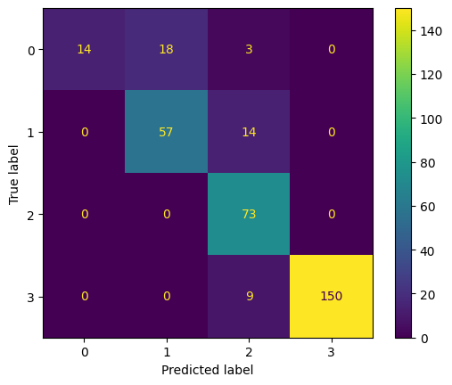

```python
#Confusion matrix OVR LR
ConfusionMatrixDisplay.from_estimator(clf_lr_ovr, X_test_mc, y_test_mc)
```

For logistic regression, we can also directly train a multi-class classifier using the multi-class cross-entropy loss (sklearn calls this the multinomial cross-entropy loss).  
−Develop and train a multi-class logistic regression model (parameter multi_class=’multinomial’)

```python
clf_lr_mult = LogisticRegression(
    multi_class='multinomial',
    solver='lbfgs',
    max_iter=1000,
    random_state=4720
)

# Train the model
clf_lr_mult.fit(X_train_mc, y_train_mc)

# Make predictions
y_prediction_lrmult = clf_lr_mult.predict(X_test_mc)
```

− Calculate and print the accuracy of the model.

```python
#Accuracy of Mult LR
Accuracy_lrmult = accuracy_score(y_test_mc,y_prediction_lrmult)
print("Accuracy: " + str(Accuracy_lrmult))
```

```
Accuracy: 0.9171597633136095
```

−Generate and plot the confusion matrix.

```
<sklearn.metrics._plot.confusion_matrix.ConfusionMatrixDisplay at 0x1c006c71b50>
```

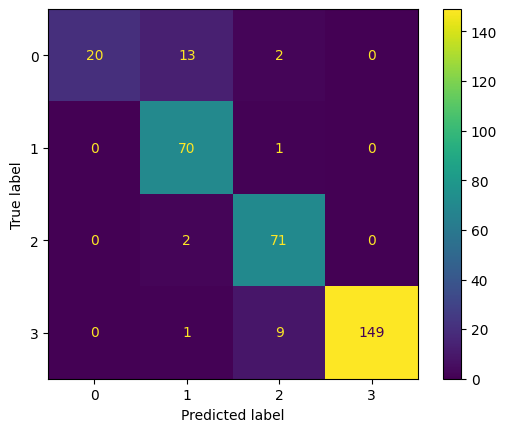

```python
#Confusion matrix mult LR
ConfusionMatrixDisplay.from_estimator(clf_lr_mult, X_test_mc, y_test_mc)
```

SVM can be used in multi-class classification tasks as well, but it will rely on the one-versus-all approach (or, for non-linear kernels, on the related one-versus-one approach).

- Develop and train a linear SVC [kernel=’linear’] as a one vs. all classifier with the given parameters [C=1.0, coef0=0.0, tol=1e-3].

```python
#OVR SVM
clf_svmlin_mc_ovr = svm.SVC(
    kernel='linear',
    degree=3,
    C=1.0,
    coef0=0.0,
    tol=1e-3,
    random_state=Shuffle_state
)

# Train the model
clf_svmlin_mc_ovr.fit(X_train_mc, y_train_mc)
y_prediction_svmovr = clf_svmlin_mc_ovr.predict(X_test_mc)
```

− Calculate and print the accuracy of the model.

```python
#Accuracy of SVM
Accuracy_svmovr = accuracy_score(y_test_mc,y_prediction_svmovr)
print("Accuracy: " + str(Accuracy_svmovr))
```

```
Accuracy: 0.9497041420118343
```

−Generate and plot the confusion matrix.

```
<sklearn.metrics._plot.confusion_matrix.ConfusionMatrixDisplay at 0x1c0046c4920>
```

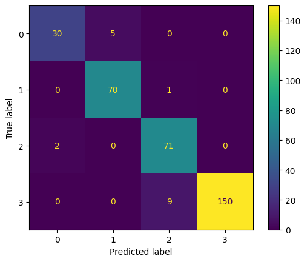

```python
#Confusion matrix SVM OVR
ConfusionMatrixDisplay.from_estimator(clf_svmlin_mc_ovr, X_test_mc, y_test_mc)
```

Questions:  
1) How does the performance change for both classification methods for the logistic regression and why?  
2) Which classification method is more computationally demanding and why?  
3) Why other classification metrics cannot be used directly in multi-class classification tasks?  
4) Why can multi-class classification be directly applied to logistic regression but not SVM?  
5) Compare all three models’ performance in multi-class classification.  
6) Which classes have higher mismatches in logistic regression?  
7) Which classes have higher mismatches in SVM?

### Bonus Task

Conduct a multi-class classification using only binary classifiers. You can use either logistic regression or SVM. Describe the steps you follow and how it works. Calculate each classifier’s output probabilities for the test data and plot them in ascending order.